# 206_Assignment_5

Tess Hooper

12/2/2018

## Step 1. Load packages and read in data.

Part 1: Male and female graduate enrollment (1967 - 2015)

## Compare trends in total graduate enrollment for males and females (use Totals) in the United States from 1967 - 2015. Describe your results statistically, graphically and in text.

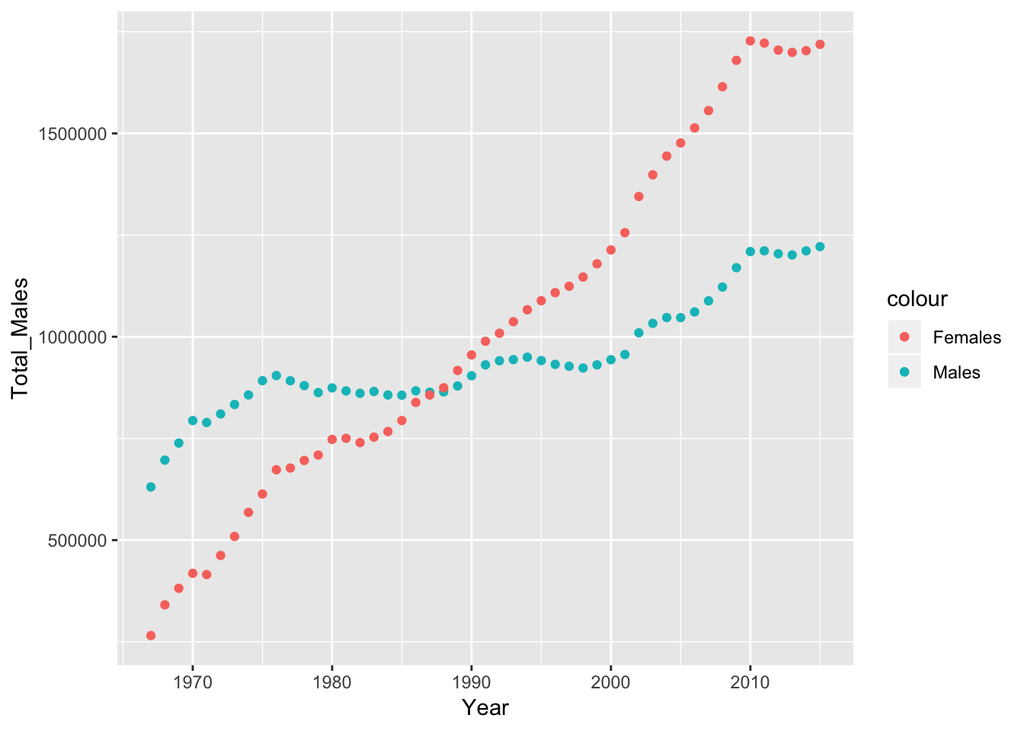

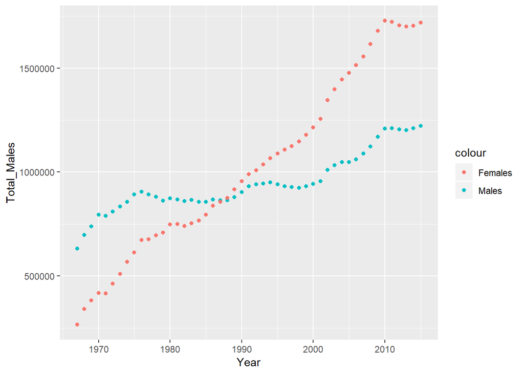

```
##
## Call:
## lm(formula = grad_enroll$Total_Females ~ grad_enroll$Year)
##
## Coefficients:
##      (Intercept)  grad_enroll$Year
##        -58955502             30126
```

```
##
## Call:
## lm(formula = grad_enroll$Total_Males ~ grad_enroll$Year)
##
## Coefficients:
##      (Intercept)  grad_enroll$Year
##        -17112153              9069
```

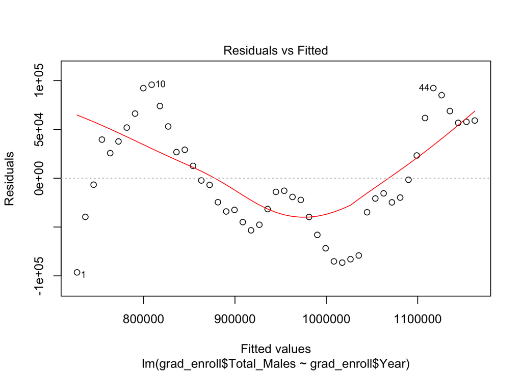

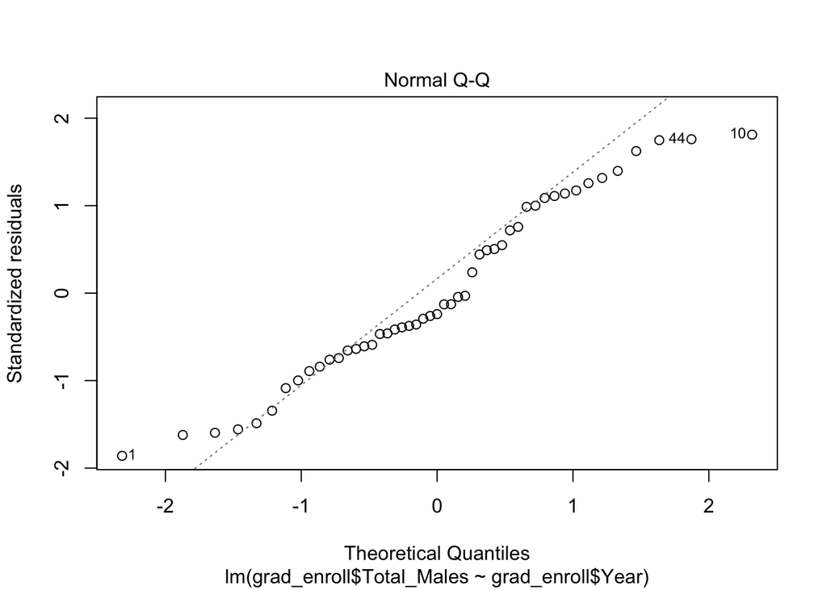

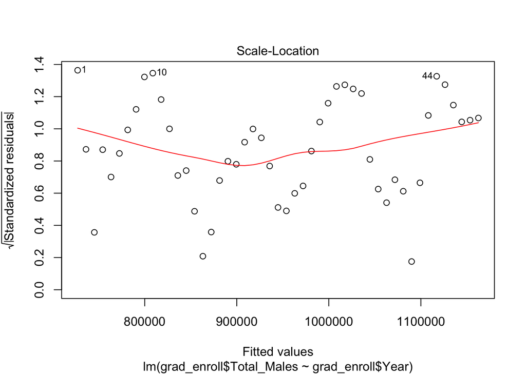

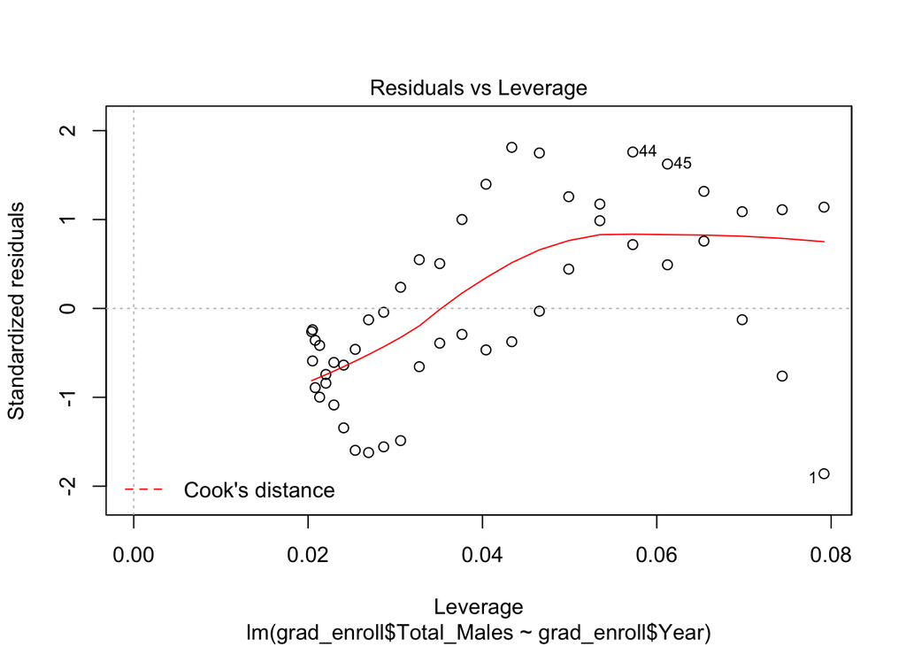

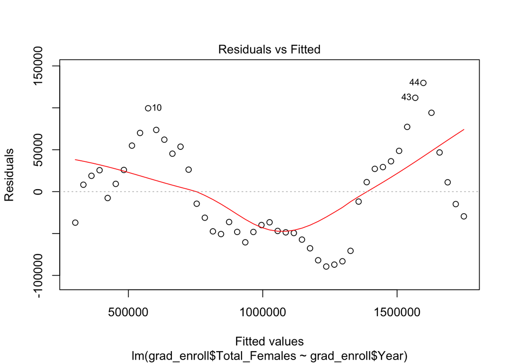

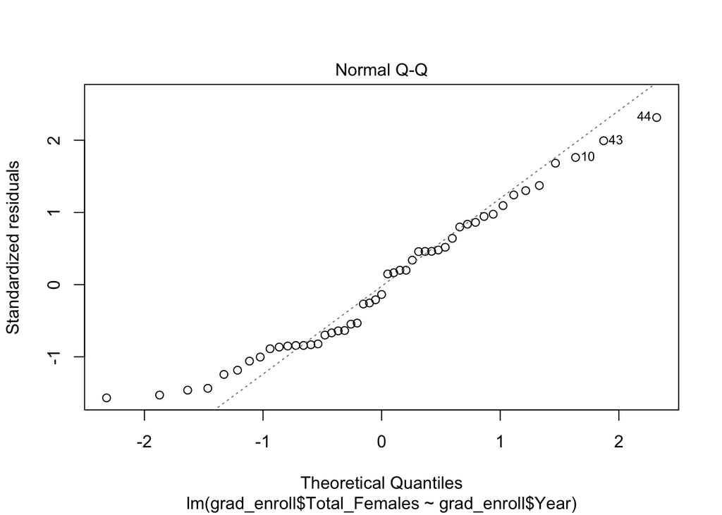

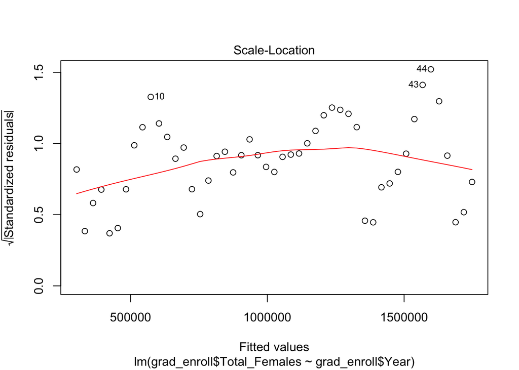

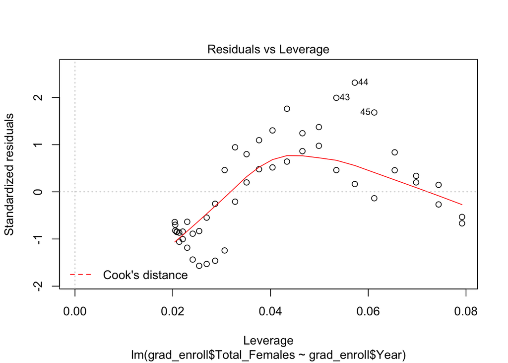

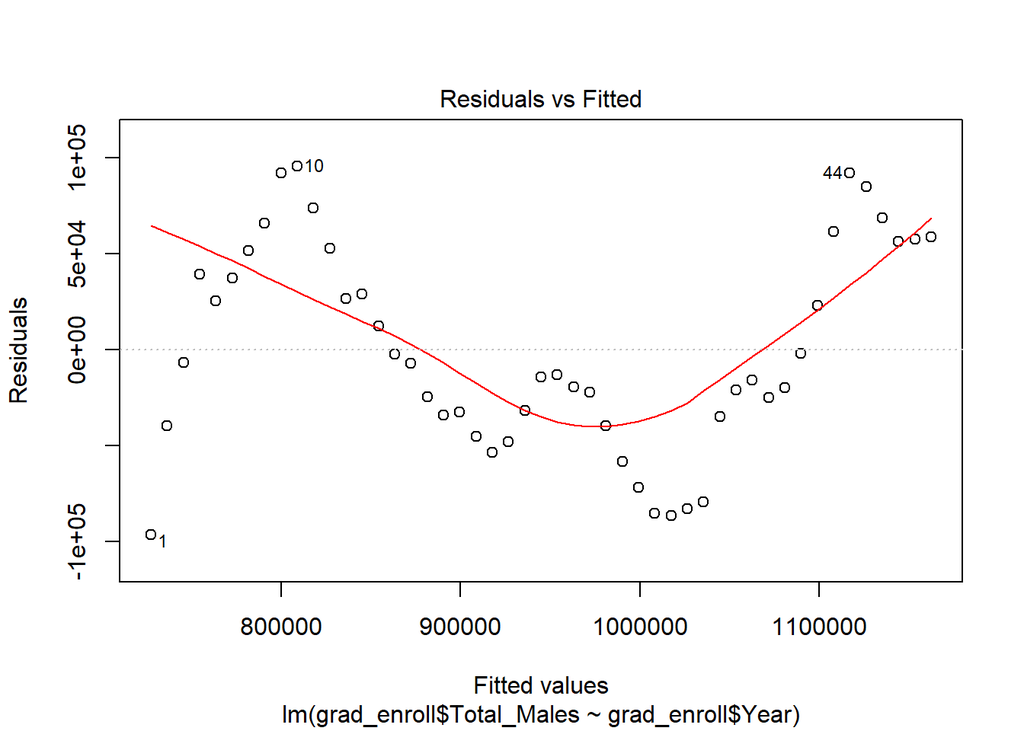

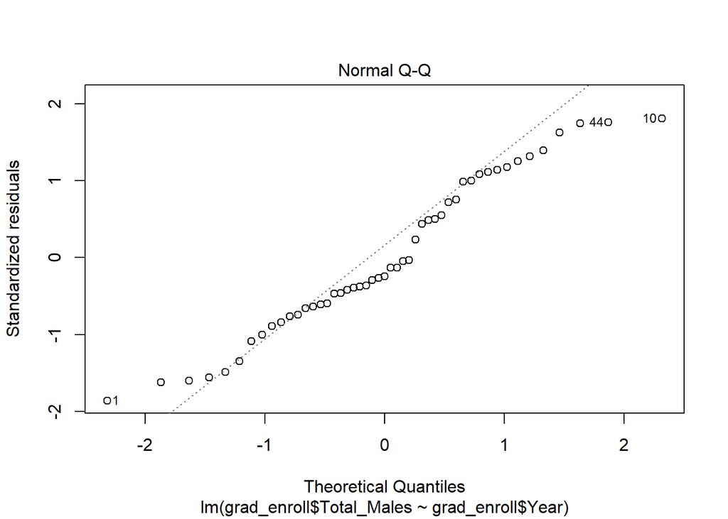

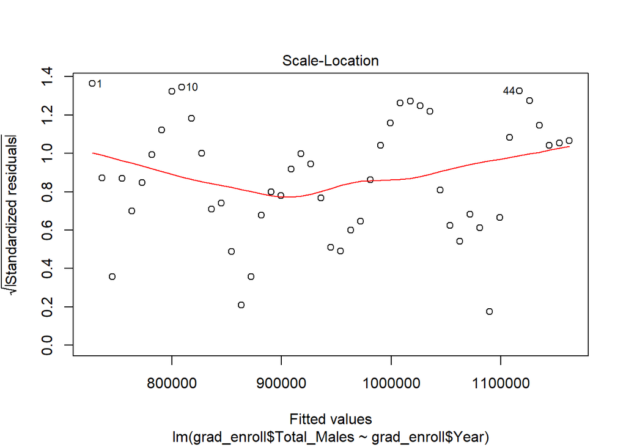

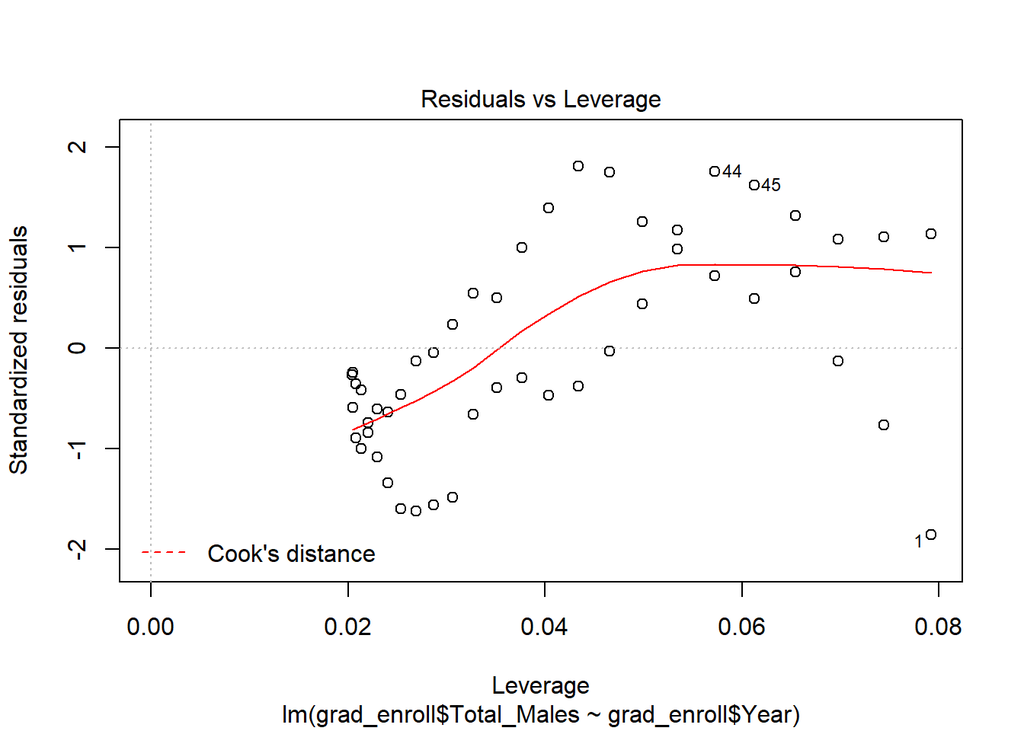

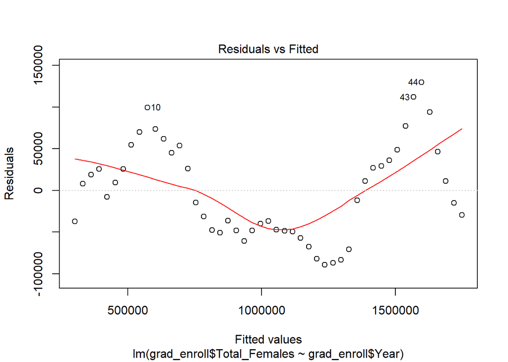

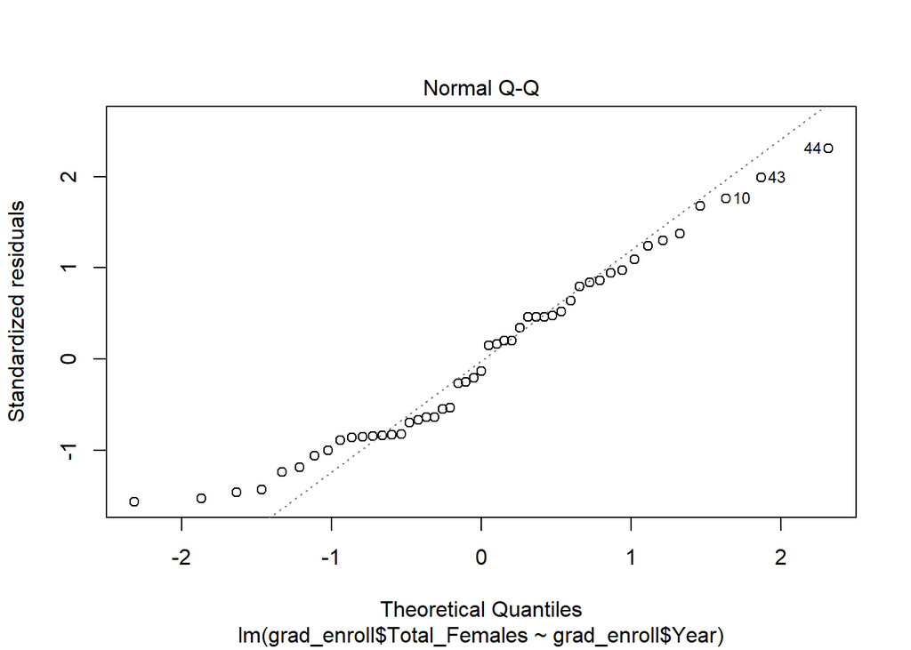

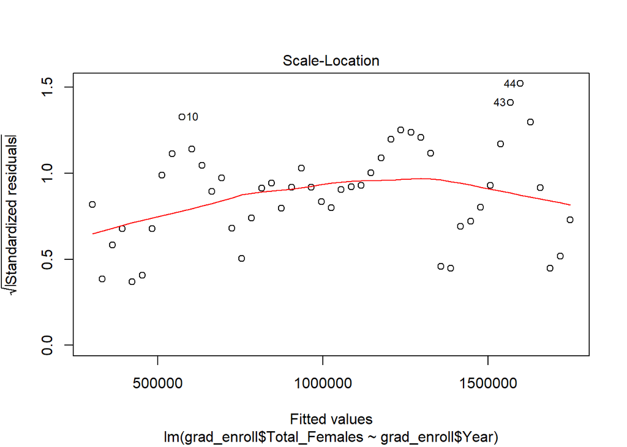

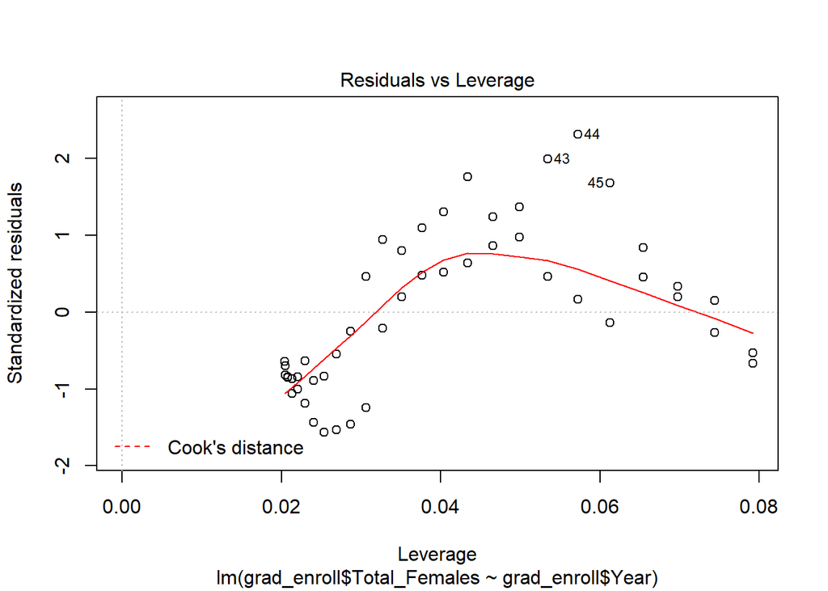

```
##
## Call:
## lm(formula = grad_enroll$Total_Females ~ grad_enroll$Year)
##
## Residuals:
##    Min     1Q Median     3Q    Max
## -89397 -48101  -7633  45267 129727
##
## Coefficients:
##                    Estimate Std. Error t value Pr(>|t|)
## (Intercept)      -5.896e+07  1.161e+06  -50.77   <2e-16 ***
## grad_enroll$Year  3.013e+04  5.832e+02   51.66   <2e-16 ***
## ---
## Signif. codes:  0 '***' 0.001 '**' 0.01 '*' 0.05 '.' 0.1 ' ' 1
##
## Residual standard error: 57730 on 47 degrees of freedom
## Multiple R-squared:  0.9827, Adjusted R-squared:  0.9823
## F-statistic:  2669 on 1 and 47 DF,  p-value: < 2.2e-16
```

```
##
## Call:
## lm(formula = grad_enroll$Total_Males ~ grad_enroll$Year)
##
## Residuals:
##    Min     1Q Median     3Q    Max
## -96461 -34861 -12841  51876  95766
##
## Coefficients:
##                   Estimate Std. Error t value Pr(>|t|)
## (Intercept)      -17112153    1087024  -15.74   <2e-16 ***
## grad_enroll$Year      9069        546   16.61   <2e-16 ***
## ---
## Signif. codes:  0 '***' 0.001 '**' 0.01 '*' 0.05 '.' 0.1 ' ' 1
##
## Residual standard error: 54050 on 47 degrees of freedom
## Multiple R-squared:  0.8545, Adjusted R-squared:  0.8514
## F-statistic:   276 on 1 and 47 DF,  p-value: < 2.2e-16
```

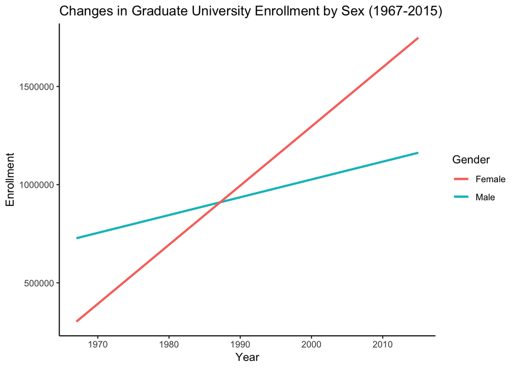

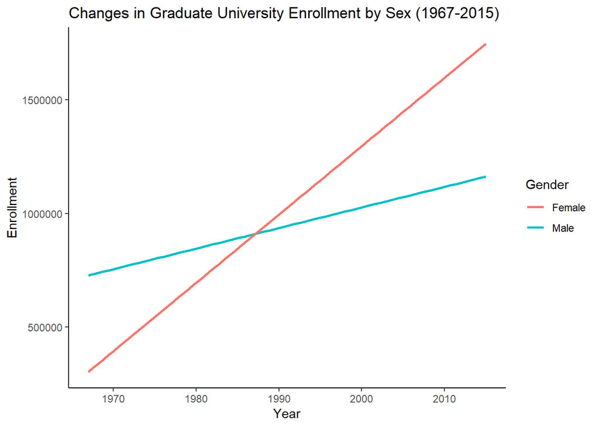

```
##
##  Pearson's product-moment correlation
##
## data:  grad_enroll$Year and grad_enroll$Total_Females
## t = 51.659, df = 47, p-value < 2.2e-16
## alternative hypothesis: true correlation is not equal to 0
## 95 percent confidence interval:
##  0.9845609 0.9951144
## sample estimates:
##       cor
## 0.9913086
```

```
##
##  Pearson's product-moment correlation
##
## data:  grad_enroll$Year and grad_enroll$Total_Males
## t = 16.612, df = 47, p-value < 2.2e-16
## alternative hypothesis: true correlation is not equal to 0
## 95 percent confidence interval:
##  0.8690777 0.9568547
## sample estimates:
##       cor
## 0.9243741
```

```
##
## ===================================================================
##                                        Dependent variable:
##                               -------------------------------------
##                                 Total_Females       Total_Males
##                                      (1)                (2)
## -------------------------------------------------------------------
## Year                            30,126.030***       9,069.301***
##                                   (583.175)          (545.955)
##
## Constant                      -58,955,502.000*** -17,112,153.000***
##                                (1,161,132.000)    (1,087,024.000)
##
## -------------------------------------------------------------------
## Observations                          49                 49
## R2                                  0.983              0.854
## Adjusted R2                         0.982              0.851
## Residual Std. Error (df = 47)     57,731.420         54,046.810
## F Statistic (df = 1; 47)         2,668.611***        275.952***
## ===================================================================
## Note:                                   *p<0.1; **p<0.05; ***p<0.01
```

# ##Part 2. Shifts in female PhD recipients by field (1985, 2000, and 2015).

1. Describe if and how there was a shift in PhDs awarded to females in Physical and Earth Sciences, Engineering, Education, and Humanities & Arts in 1985, 2000, and 2015.
2. Describe in a graph or table.
3. Describe in text and statistically.

# Note: several ways to interpret this question: decide which you think is/are most interesting. state which you are asking/answering in your report.

```
## # A tibble: 12 x 5
##    field             sex     year number percent
##    <chr>             <chr>  <int>  <dbl>   <dbl>
##  1 Physical Sciences female  1985    569   0.163
##  2 Engineering       female  1985    198   0.063
##  3 Education         female  1985   3491   0.518
##  4 Arts & Humanities female  1985   1392   0.409
##  5 Physical Sciences female  2000   1022   0.252
##  6 Engineering       female  2000    838   0.158
##  7 Education         female  2000   4179   0.649
##  8 Arts & Humanities female  2000   2672   0.49
##  9 Physical Sciences female  2015   1988   0.336
## 10 Engineering       female  2015   2301   0.232
## 11 Education         female  2015   3502   0.685
## 12 Arts & Humanities female  2015   2832   0.506
```

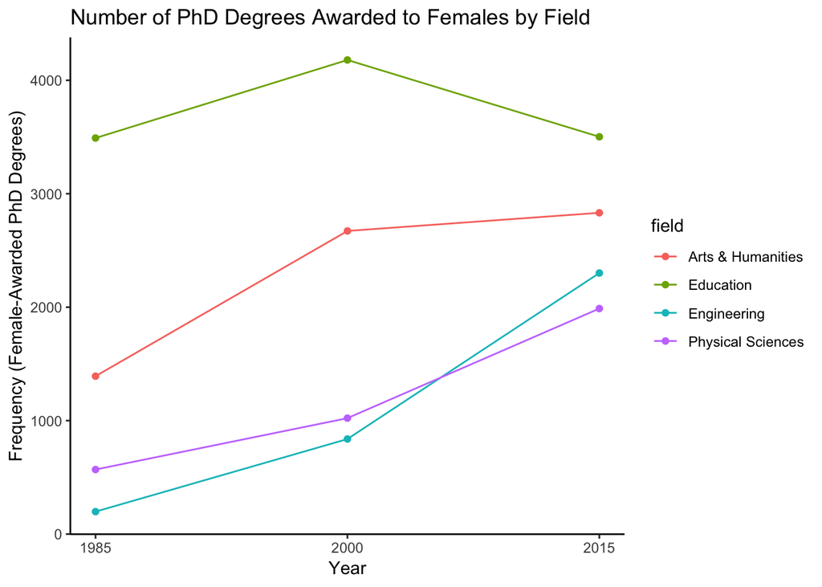

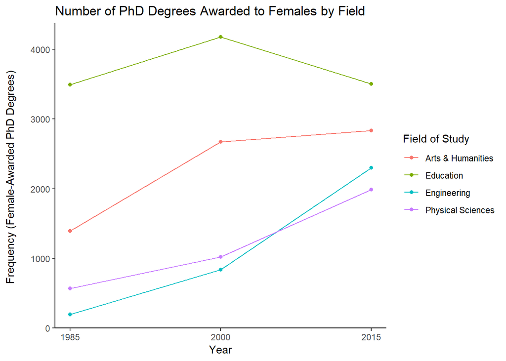

```r
#1. Use chi-squared to explore changes in PhD proportions between fields over time. Are we testing ito see if there is a

#Null hypothesis (H0): There is no significant association between number of degrees awarded and field of study
#Alternative hypothesis (Ha): There is a significant association between number of degrees awarded and field of study.

x2_test <- chisq.test(chi_females)


x2_test
```

```
##
##  Pearson's Chi-squared test
##
## data:  chi_females
## X-squared = 2073.3, df = 6, p-value < 2.2e-16
```

```r
#interested in showing the changes in proportions of number of degrees between the categories across the 3 years. We also want to show total increase or decrease in number of PhD degrees per category.


###p-value is <0.001. There IS a significant association between number of degrees awarded and field of study.
### x2(6)= 2073.3, p<0.001
```

## Part 3: Male and female salaries for starting postdoctoral and other employment positions (2015).

Compare median salaries for male and female doctorate recipients in 2015. Answer these two questions:

A. Does median salary differ significantly between male and female starting postdoc positions?

B. Does median salary differ significantly between male and female PhD recipients in non-postdoc employment positions?

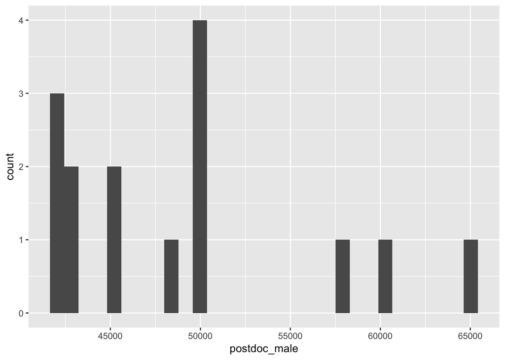

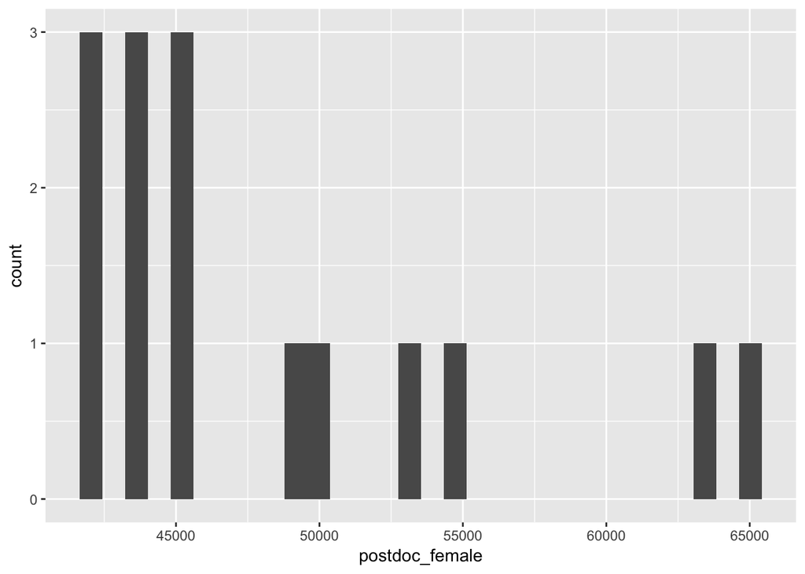

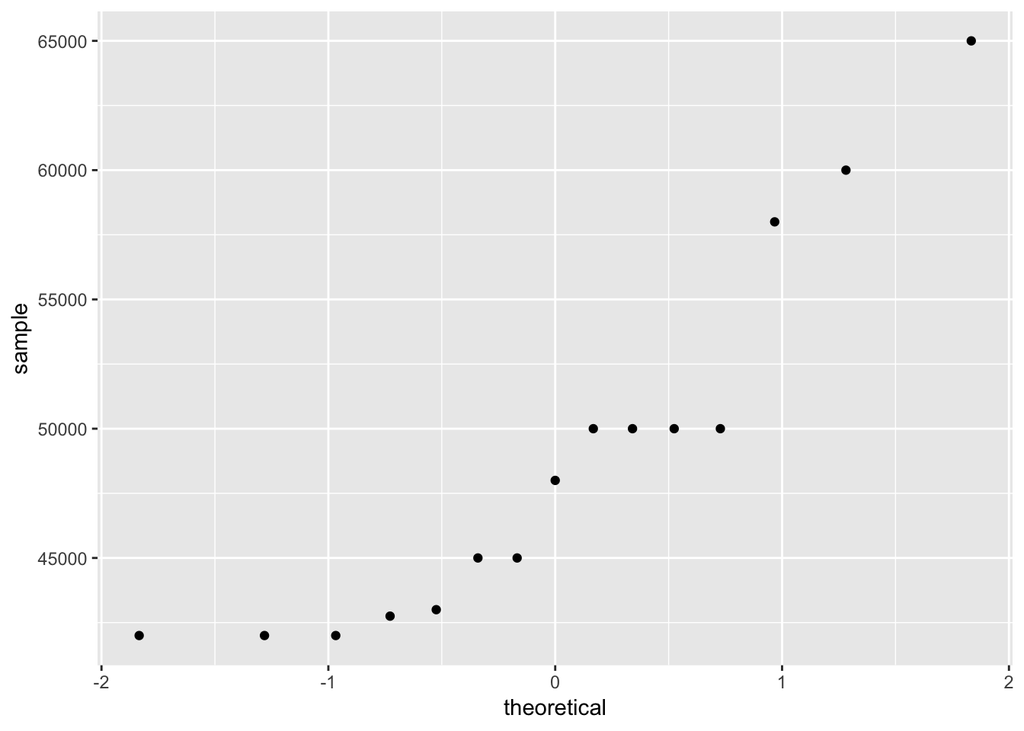

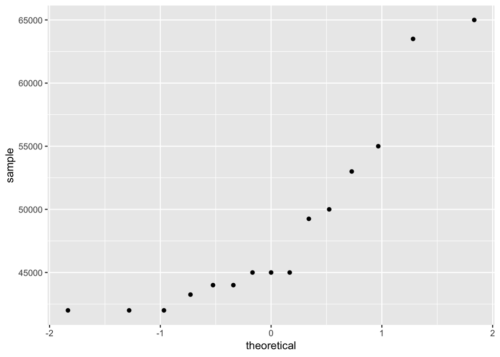

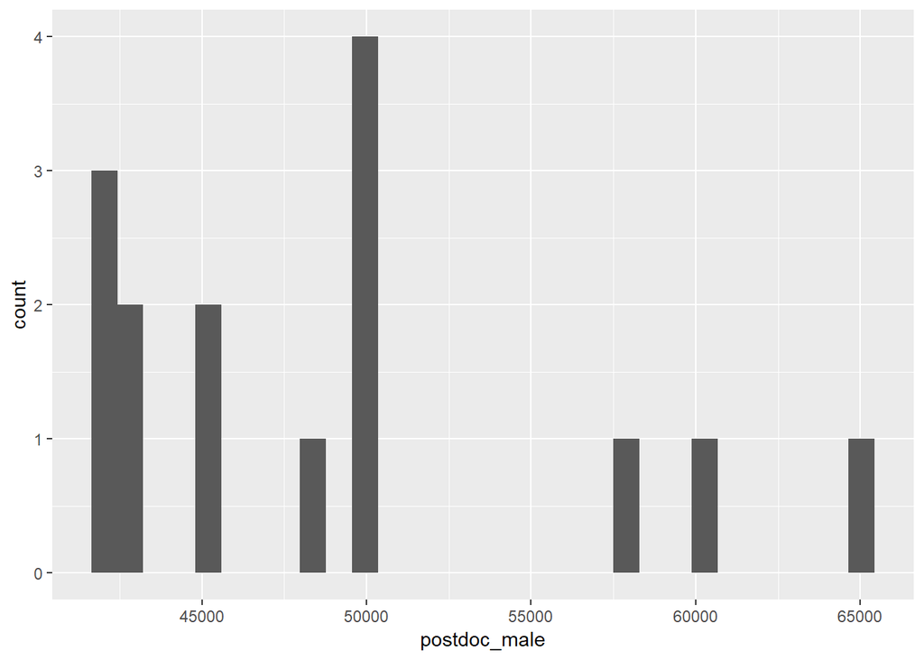

```r
#Ways to explore the medians: Mann-Whitney U and Wilcoxen Signed Rank
#Mann-Whiteney U is the non paired test

#Explore the Data with histograms

postdoc_hist_male <- ggplot(median_salary, aes(x= postdoc_male)) +
  geom_histogram()

postdoc_hist_male
```

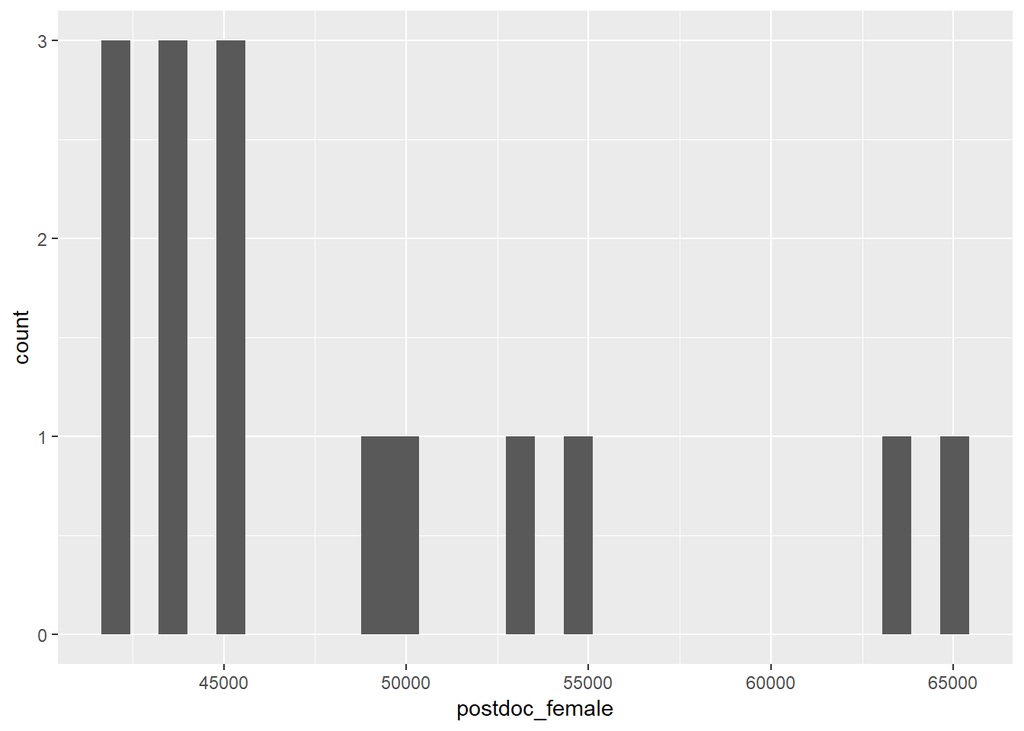

```r
postdoc_hist_female <- ggplot(median_salary, aes(x = postdoc_female))+
  geom_histogram()

postdoc_hist_female
```

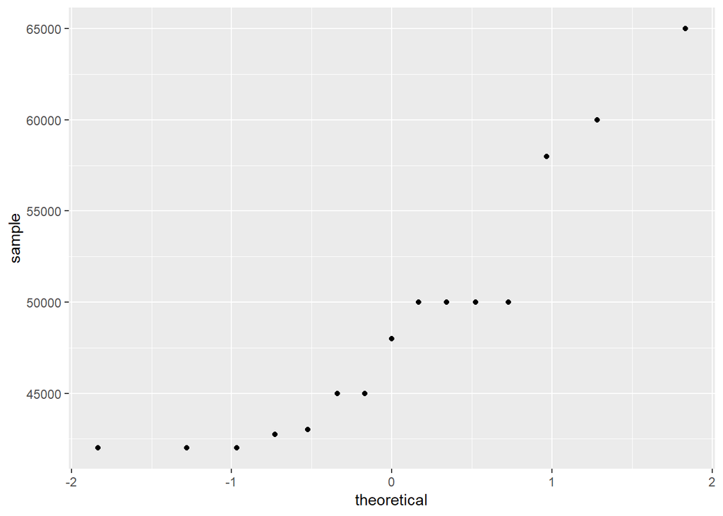

```r
postdoc_qq_male <- ggplot(median_salary, aes(sample = postdoc_male))+
  geom_qq()

postdoc_qq_male
```

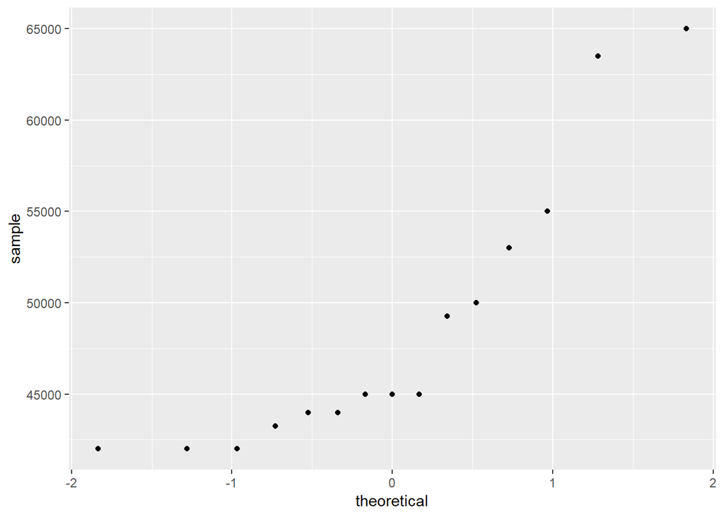

```r
postdoc_qq_female <- ggplot(median_salary, aes(sample = postdoc_female)) +
  geom_qq()

postdoc_qq_female
```

```r
#no assupmtion of normality necessary, no outliers


#Wilcox test because data is paired

#H0: The medians will not be signifigantly different between male and female postdoc salaries

#HA: The medians will be signifigantly different between male and female postdoc salaries

postdoc_salary_wilcox <- wilcox.test(median_salary$postdoc_male, median_salary$postdoc_female, paired = TRUE)
postdoc_salary_wilcox
```

```
##
##  Wilcoxon signed rank test with continuity correction
##
## data:  median_salary$postdoc_male and median_salary$postdoc_female
## V = 19.5, p-value = 0.8884
## alternative hypothesis: true location shift is not equal to 0
```

```r
#V = 19.5, p-value = 0.8884
#There is no signifigant difference between males and females in postdoctoral positions

#Employment in non-postdoc positions
employment_salary_wilcox <- wilcox.test(median_salary$employment_male, median_salary$employment_female, paired = TRUE)
employment_salary_wilcox
```

```
##
##  Wilcoxon signed rank test with continuity correction
##
## data:  median_salary$employment_male and median_salary$employment_female
## V = 101, p-value = 0.002572
## alternative hypothesis: true location shift is not equal to 0
```

```r
#V = 101, p-value = 0.002572
#There is a signifigant difference between males and females in non-postdoctoral postions
```

There is no signifigant difference between males and females in postdoctoral positions (V = 19.5 , *p* = 0.888 , $\alpha$ = 0.05).

There is a signifigant difference between males and females in non-postdoctoral employment positions (V = 101 , *p* = 0.003 , $\alpha$ = 0.05).